# Biostat 212a Homework 5

Due Mar 16, 2024 @ 11:59PM

Author

Wenqiang Ge UID:106371961

Published

March 11, 2025

## 1 ISL Exercise 9.7.1 (10pts)

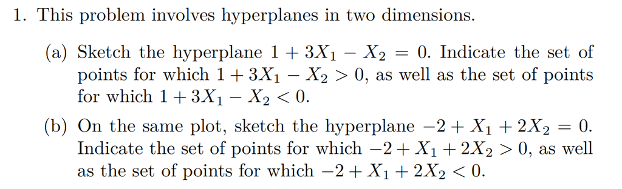

Solution:

(a)

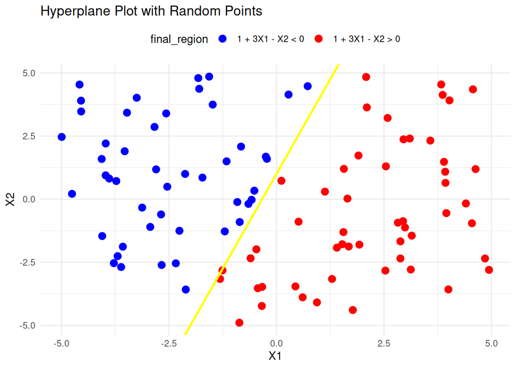

```r
# Load necessary libraries
library(ggplot2)
library(dplyr)

# Generate random points
set.seed(123)  # For reproducibility
points <- data.frame(
  X1 = runif(100, min = -5, max = 5),  # Random X1 values
  X2 = runif(100, min = -5, max = 5)   # Random X2 values
)

# Define hyperplane equation
hyperplane_1 <- function(X1) { 1 + 3*X1 }  # Equation for hyperplane 1

# Calculate the corresponding values of X2
points$hyperplane_1_result <- 1 + 3*points$X1 - points$X2  # Evaluate the hyperplane equation

# Assign category labels for each point based on hyperplane condition
points$region_1 <- ifelse(points$hyperplane_1_result > 0, "1 + 3X1 - X2 > 0", "1 + 3X1 - X2 < 0")

# Combine the region labels to distinguish the points based on the regions
points$final_region <- paste(points$region_1)

# Create the plot
ggplot(points) +
  # Plot random points with color based on region
  geom_point(aes(x = X1, y = X2, color = final_region), size = 3) +
  # Plot the hyperplane line
  geom_abline(intercept = 1, slope = 3, color = "yellow", size = 1) +  # Hyperplane: 1 + 3X1 - X2 = 0
  labs(title = "Hyperplane Plot with Random Points", x = "X1", y = "X2") +  # Set plot title and axis labels
  theme_minimal() +  # Use minimal theme for cleaner plot
  theme(legend.position = "top") +  # Position the legend at the top
  scale_color_manual(values = c("blue", "red"))  # Set colors for the regions
```

(b)

[figure not shown]

```r
set.seed(123)  # For reproducibility
points <- data.frame(
  X1 = runif(100, min = -5, max = 5),  # Random X1 values
  X2 = runif(100, min = -5, max = 5)   # Random X2 values
)

# Define hyperplane equations
hyperplane_1 <- function(X1) { 1 + 3*X1 }
hyperplane_2 <- function(X1) { (-2 + X1) / 2 }

# Calculate corresponding X2 values
points$hyperplane_1_result <- 1 + 3*points$X1 - points$X2
points$hyperplane_2_result <- -2 + points$X1 + 2*points$X2

# Assign category labels for each point
points$region_1 <- ifelse(points$hyperplane_1_result > 0, "1 + 3X1 - X2 > 0", "1 + 3X1 - X2 < 0")
points$region_2 <- ifelse(points$hyperplane_2_result > 0, "-2 + X1 + 2X2 > 0", "-2 + X1 + 2X2 < 0")

# Combine both labels to distinguish different regions of the points
points$final_region <- paste(points$region_1, points$region_2)

# Plot
ggplot(points) +
  geom_point(aes(x = X1, y = X2, color = final_region), size = 3) +  # Random points with color based on regions
  geom_abline(intercept = 1, slope = 3, color = "yellow", size = 1, show.legend = FALSE) +  # Hyperplane 1 without legend
  geom_abline(intercept = -2, slope = -1/2, color = "green", size = 1, show.legend = FALSE) +  # Hyperplane 2 without legend
  labs(title = "Hyperplane Plot with Random Points", x = "X1", y = "X2") +
  scale_color_manual(values = c("blue", "red", "purple", "gray")) +  # Set 4 colors for the regions
  theme_minimal() +
  theme(
    legend.position = "right",
    legend.title = element_blank(),
    legend.text = element_text(size = 7),  # Smaller text for labels
    legend.key.size = unit(0.4, "cm"),  # Adjust legend key size for better spacing
    legend.direction = "vertical",  # Arrange labels vertically
    legend.box = "vertical",  # Stack the labels vertically
    plot.margin = margin(10, 10, 10, 10),  # Adjust margins to give more space
    aspect.ratio = 0.8  # Increase the size of the plot
  )
```

## 2 ISL Exercise 9.7.2 (10pts)

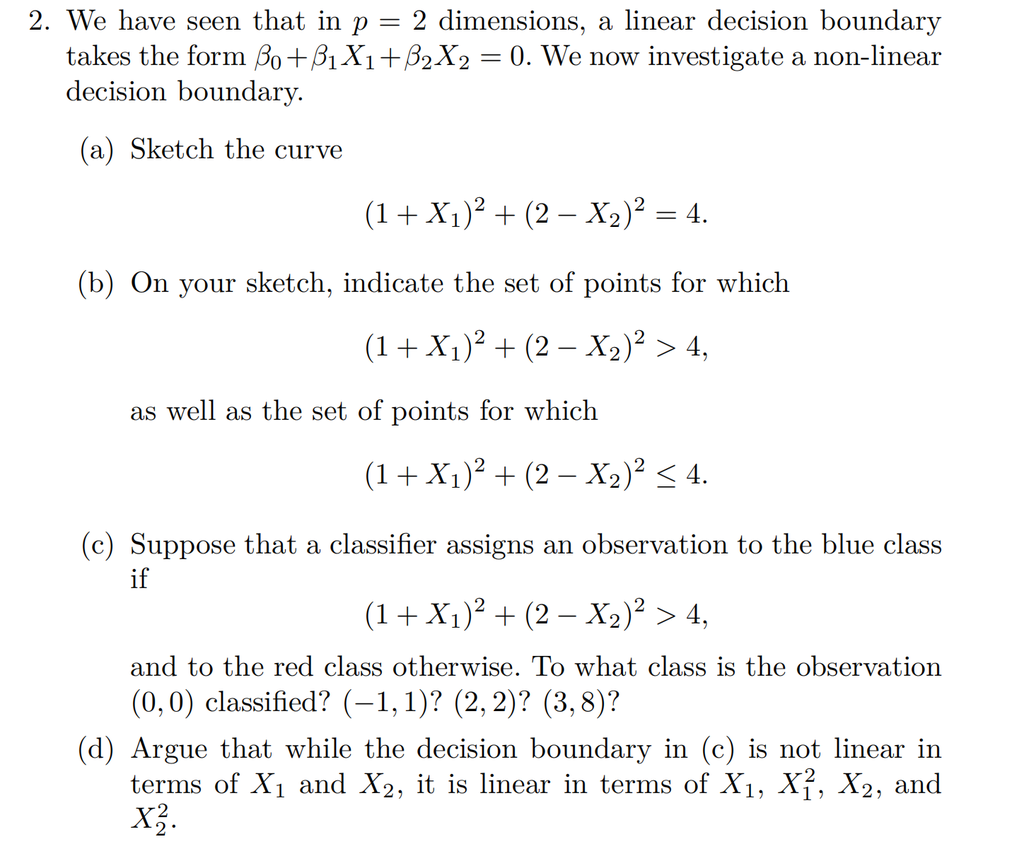

Solution:

(a)

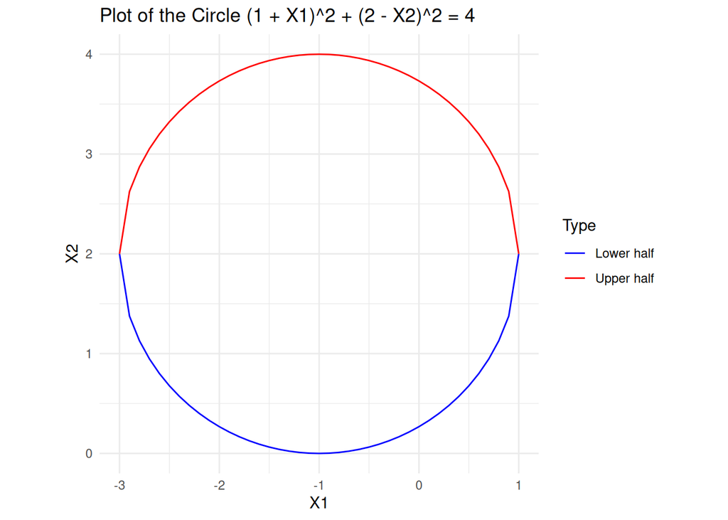

```r
# Define the circle equation
circle_eq <- function(X1) {
  sqrt(4 - (X1 + 1)^2) + 2  # Solve for X2
}

# Create X1 values and calculate corresponding X2 values
X1_values <- seq(-3, 1, by = 0.1)
X2_values_positive <- sapply(X1_values, function(X1) circle_eq(X1))
X2_values_negative <- sapply(X1_values, function(X1) -circle_eq(X1) + 4)

# Create a data frame
circle_data <- data.frame(X1 = rep(X1_values, 2),
                          X2 = c(X2_values_positive, X2_values_negative),
                          Type = rep(c("Upper half", "Lower half"), each = length(X1_values)))

# Plot the circle
ggplot(circle_data, aes(x = X1, y = X2, color = Type)) +
  geom_line() +
  labs(title = "Plot of the Circle (1 + X1)^2 + (2 - X2)^2 = 4", x = "X1", y = "X2") +
  theme_minimal() +
  scale_color_manual(values = c("blue", "red")) +
  coord_fixed(ratio = 1)
```

(b)

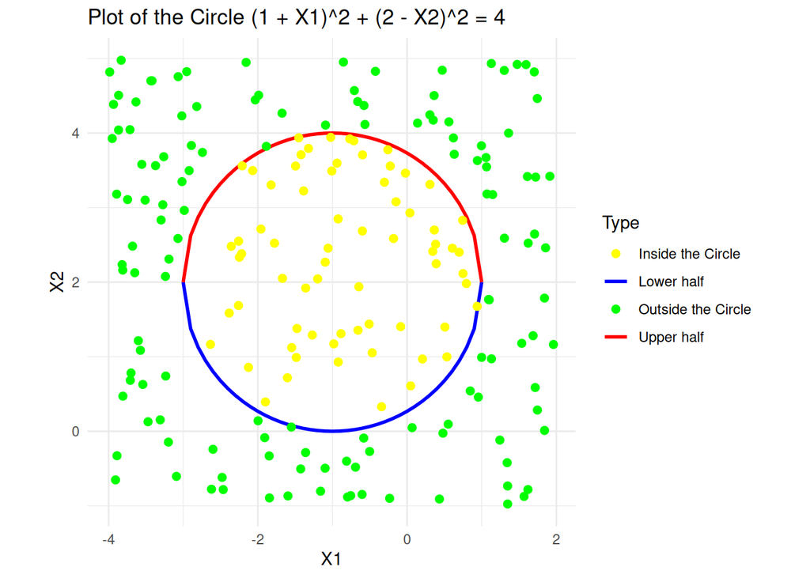

```r
# Define random points to classify as inside or outside the circle
set.seed(213)  # For reproducibility
points <- data.frame(
  X1 = runif(200, min = -4, max = 2),  # Random X1 values
  X2 = runif(200, min = -1, max = 5)   # Random X2 values
)

# Calculate the circle equation for each point
points$circle_equation <- (1 + points$X1)^2 + (2 - points$X2)^2

# Assign categories based on whether points are inside or outside the circle
points$region <- ifelse(points$circle_equation <= 4, "Inside the Circle", "Outside the Circle")

# Plot the circle and points with different colors for the regions
ggplot() +
  geom_line(data = circle_data, aes(x = X1, y = X2, color = Type), size = 1) +  # Circle
  geom_point(data = points, aes(x = X1, y = X2, color = region), size = 2) +  # Points inside and outside the circle
  labs(title = "Plot of the Circle (1 + X1)^2 + (2 - X2)^2 = 4", x = "X1", y = "X2") +
  scale_color_manual(values = c("yellow", "blue", "green", "red")) +  # Added color for all regions
  theme_minimal() +
  coord_fixed(ratio = 1)
```

(c)

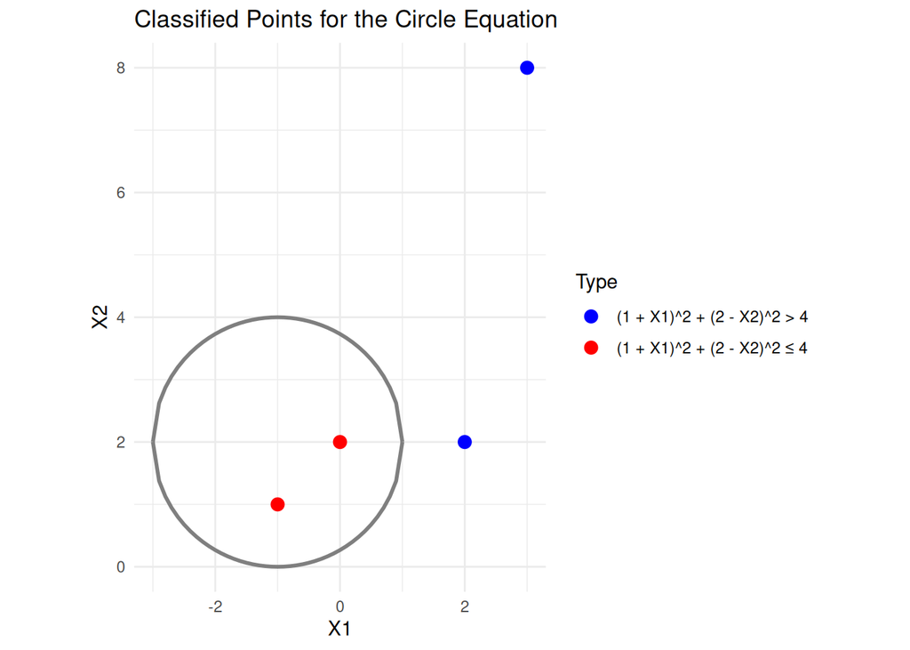

```r
# Define the circle equation
circle_eq <- function(X1) {
  sqrt(4 - (X1 + 1)^2) + 2  # Solve for X2
}

# Create X1 values and calculate corresponding X2 values
X1_values <- seq(-3, 1, by = 0.1)
X2_values_positive <- sapply(X1_values, function(X1) circle_eq(X1))
X2_values_negative <- sapply(X1_values, function(X1) -circle_eq(X1) + 4)

# Create a data frame for the circle
circle_data <- data.frame(X1 = rep(X1_values, 2),
                          X2 = c(X2_values_positive, X2_values_negative),
                          Type = rep(c("Upper half", "Lower half"), each = length(X1_values)))

# Points for classification
specific_points <- data.frame(
  X1 = c(0, -1, 2, 3),  # X1 values
  X2 = c(2, 1, 2, 8)    # X2 values
)

# Classify the points
specific_points$classification <- ifelse(
  (1 + specific_points$X1)^2 + (2 - specific_points$X2)^2 > 4, "(1 + X1)^2 + (2 - X2)^2 > 4", "(1 + X1)^2 + (2 - X2)^2 ≤ 4"
)

# Plot the circle and points with different colors for the regions
ggplot() +
  geom_line(data = circle_data, aes(x = X1, y = X2, color = Type), size = 1
            ) +  # Plot circle
  geom_point(data = specific_points, aes(x = X1, y = X2, color = classification), size = 3) +  # Plot classified points
  labs(title = "Classified Points for the Circle Equation", x = "X1", y = "X2") +
  scale_color_manual(values = c("(1 + X1)^2 + (2 - X2)^2 > 4" = "blue", "(1 + X1)^2 + (2 - X2)^2 ≤ 4" = "red")) +  # Set colors for blue and red
  theme_minimal() +
  coord_fixed(ratio =1)
```

(d) The decision boundary in part (c) is given by the equation:$(1+X_1)^2+(2-X_2)^2 = 4$. After expand above equation, we get:

$1+{X_1}^2+2X_1+4+{X_2}^2-4X_2 = 4$

In this equation, we have these items $X_1,X_2,{X_1}^2,{X_2}^2$.

This shows that the decision boundary is quadratic when expressed in terms of the original features $X_1$ and $X_2$. However, if we introduce new features such as ${X_1}^2$ and ${X_2}^2$ (which are the squared versions of $X_1$ and $X_2$), the decision boundary becomes linear in terms of these new features because the equation will now only involve linear terms in $X_1$, $X_2$, ${X_1}^2$, and ${X_2}^2$.

## 3 Support vector machines (SVMs) on the `Carseats` data set (30pts)

Follow the machine learning workflow to train support vector classifier (same as SVM with linear kernel), SVM with polynomial kernel (tune the degree and regularization parameter $C$), and SVM with radial kernel (tune the scale parameter $\gamma$ and regularization parameter $C$) for classifying `Sales<=8` versus `Sales>8`. Use the same seed as in your HW4 for the initial test/train split and compare the final test AUC and accuracy to those methods you tried in HW4.

Solution:

```r
library(GGally)
library(gtsummary)
library(kernlab)
library(tidyverse)
library(tidymodels)
library(ISLR2)
library(caret)
library(doParallel)
library(vip)
library(doParallel)
```

```r
# load the data
data("Carseats", package = "ISLR2")
Carseats$Sales<- ifelse(Carseats$Sales > 8, "High", "Low")
Carseats$Sales <- as.factor(Carseats$Sales)
```

#### 3.0.1 **Initial split into test and non-test sets**

```r
#Initial split into test and non-test sets
set.seed(212)
data_split <- initial_split(
  Carseats,
  prop = 0.75,
  strata = Sales
  )
data_split
```

```
<Training/Testing/Total>
<300/100/400>
```

```r
Carseats_other <- training(data_split)
dim(Carseats_other)
```

```
[1] 300  11
```

```r
Carseats_test <- testing(data_split)
dim(Carseats_test)
```

```
[1] 100  11
```

#### 3.0.2 Recipe

```r
svm_recipe <-
  recipe(
    Sales ~ .,
    data = Carseats_other
  ) %>%
  # create traditional dummy variables (necessary for svm)
  step_dummy(all_nominal_predictors()) %>%
  # zero-variance filter
  step_zv(all_numeric_predictors()) %>%
  # center and scale numeric data
  step_normalize(all_numeric_predictors()) # %>%
  # estimate the means and standard deviations
  # prep(training = Heart_other, retain = TRUE)
svm_recipe
```

### 3.1 SVM with linear kernel

#### 3.1.1 Model & Workflow

```r
svm_linear_mod <-
  svm_linear(
    mode = "classification",
    cost = tune()
) %>%
  set_engine("kernlab")
svm_linear_mod
```

```
Linear Support Vector Machine Model Specification (classification)

Main Arguments:
  cost = tune()

Computational engine: kernlab
```

```r
svm_linear_wf <- workflow() %>%
  add_recipe(svm_recipe) %>%
  add_model(svm_linear_mod)
```

#### 3.1.2 Tuning grid

```r
param_grid <- grid_regular(
  cost(range = c(-3, 2)),
  #scale_factor(range = c(-1, 1)),
  levels = c(5)
  )
param_grid
```

```
# A tibble: 5 × 1
   cost
  <dbl>
1 0.125
2 0.297
3 0.707
4 1.68
5 4
```

#### 3.1.3 Cross-validation

```r
set.seed(212)

folds <- vfold_cv(Carseats_other, v = 5)
folds
```

```
#  5-fold cross-validation
# A tibble: 5 × 2
  splits           id
  <list>           <chr>
1 <split [240/60]> Fold1
2 <split [240/60]> Fold2
3 <split [240/60]> Fold3
4 <split [240/60]> Fold4
5 <split [240/60]> Fold5
```

```r
# Fit cross-validation
svm_linear_fit <-
  svm_linear_wf %>%
  tune_grid(
    resamples = folds,
    grid = param_grid,
    metrics = metric_set(roc_auc, accuracy)
  )
```

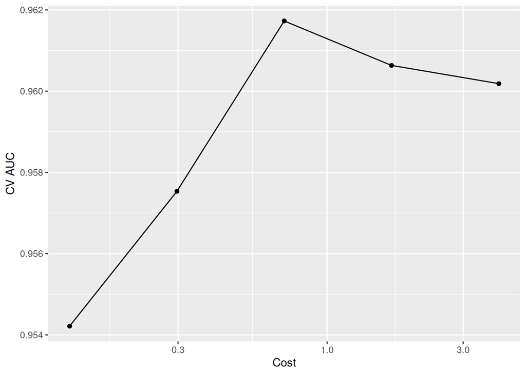

```r
#Visualize CV results
svm_linear_fit %>%
  collect_metrics() %>%
  filter(.metric == "roc_auc") %>%
  ggplot(aes(x = cost, y = mean)) +
  geom_line() +
  geom_point() +
  labs(x = "Cost",
       y = "CV AUC") +
  scale_x_log10()
```

```r
best_linear <- svm_linear_fit %>%
  select_best(metric = "roc_auc")
best_linear
```

```
# A tibble: 1 × 2
   cost .config
  <dbl> <chr>
1 0.707 Preprocessor1_Model3
```

#### 3.1.4 Finalize the model

```r
# Final workflow
final_linear_wf <-
  svm_linear_wf %>%
  finalize_workflow(
    best_linear
  )
# fit the whole training set, then predict test
final_linear_fit <-
  final_linear_wf %>%
  last_fit(data_split)

# test metrics
final_linear_fit %>%
  collect_metrics()
```

```
# A tibble: 3 × 4
  .metric     .estimator .estimate .config
  <chr>       <chr>          <dbl> <chr>
1 accuracy    binary         0.84  Preprocessor1_Model1
2 roc_auc     binary         0.944 Preprocessor1_Model1
3 brier_class binary         0.100 Preprocessor1_Model1
```

#### 3.1.5 Visualize the final model

```r
set.seed(212)
split_obj <- initial_split(data = Carseats, prop = 0.75, strata = Sales)
train <- training(split_obj)
test <- testing(split_obj)

# Create the recipe
recipe(Sales ~ ., data = train) %>%
  # create traditional dummy variables (necessary for svm)
  step_dummy(all_nominal_predictors()) %>%
  # zero-variance filter
  step_zv(all_numeric_predictors()) %>%
  # center and scale numeric data
  step_normalize(all_numeric_predictors()) %>%
  # estimate the means and standard deviations
  prep() -> recipe_obj

# Bake
train <- bake(recipe_obj, new_data=train)
test <- bake(recipe_obj, new_data=test)
```

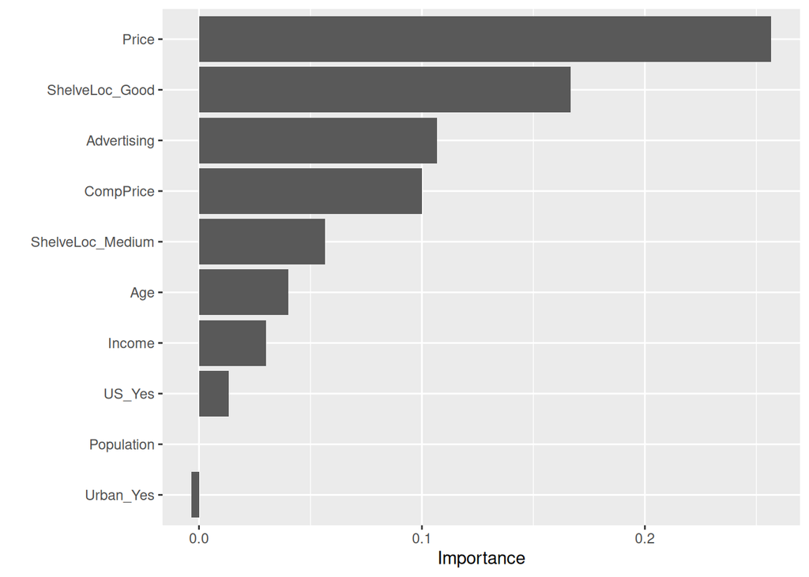

```r
final_linear_fit %>%
  pluck(".workflow", 1) %>%
  pull_workflow_fit() %>%
  # vip(method = "permute", train= Heart)
  vip(method = "permute",
      target = "Sales", metric = "accuracy",
      pred_wrapper = kernlab::predict, train = train)
```

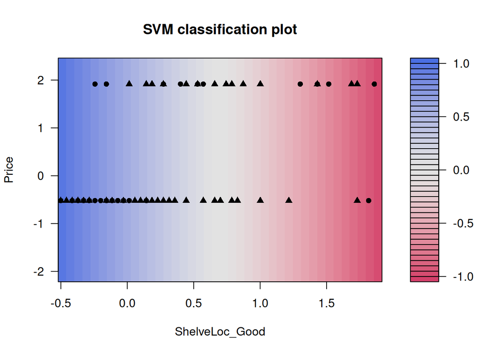

```r
# Use svm_linear() for linear kernel SVM
svm_linear_spec <- svm_linear() %>%
  set_mode("classification") %>%
  set_engine("kernlab")

# Fit the model with linear kernel
svm_linear_fit <- svm_linear_spec %>%
  fit(Sales ~ ., data = train[, c('Price', 'ShelveLoc_Good', 'Sales')])
# Visualize the decision boundary
svm_linear_fit %>%
  extract_fit_engine() %>%
  plot()
```

### 3.2 SVM with polynomial kernel

#### 3.2.1 Model & Workflow

```r
svm_mod <-
  svm_poly(
    mode = "classification",
    cost = tune(),
    degree = tune()
  ) |>
  set_engine("kernlab")
svm_mod
```

```
Polynomial Support Vector Machine Model Specification (classification)

Main Arguments:
  cost = tune()
  degree = tune()

Computational engine: kernlab
```

```r
svm_wf <- workflow() %>%
  add_recipe(svm_recipe) %>%
  add_model(svm_mod)
svm_wf
```

```
══ Workflow ════════════════════════════════════════════════════════════════════
Preprocessor: Recipe
Model: svm_poly()

── Preprocessor ────────────────────────────────────────────────────────────────
3 Recipe Steps

• step_dummy()
• step_zv()
• step_normalize()

── Model ───────────────────────────────────────────────────────────────────────
Polynomial Support Vector Machine Model Specification (classification)

Main Arguments:
  cost = tune()
  degree = tune()

Computational engine: kernlab
```

#### 3.2.2 Tuning grid

```r
param_grid <- grid_regular(
  cost(range = c(-3, 3)),
  degree(range = c(1, 5)),
  levels = c(5)
  )
param_grid
```

```
# A tibble: 25 × 2
    cost degree
   <dbl>  <dbl>
 1 0.125      1
 2 0.354      1
 3 1          1
 4 2.83       1
 5 8          1
 6 0.125      2
 7 0.354      2
 8 1          2
 9 2.83       2
10 8          2
# ℹ 15 more rows
```

#### 3.2.3 Cross-validation

```r
set.seed(212)

folds <- vfold_cv(Carseats_other, v = 5)
folds
```

```
#  5-fold cross-validation
# A tibble: 5 × 2
  splits           id
  <list>           <chr>
1 <split [240/60]> Fold1
2 <split [240/60]> Fold2
3 <split [240/60]> Fold3
4 <split [240/60]> Fold4
5 <split [240/60]> Fold5
```

```r
svm_fit <- svm_wf %>%
  tune_grid(
    resamples = folds,
    grid = param_grid,
    metrics = metric_set(roc_auc, accuracy)
    )
svm_fit
```

```
# Tuning results
# 5-fold cross-validation
# A tibble: 5 × 4
  splits           id    .metrics          .notes
  <list>           <chr> <list>            <list>
1 <split [240/60]> Fold1 <tibble [50 × 6]> <tibble [0 × 3]>
2 <split [240/60]> Fold2 <tibble [50 × 6]> <tibble [0 × 3]>
3 <split [240/60]> Fold3 <tibble [50 × 6]> <tibble [0 × 3]>
4 <split [240/60]> Fold4 <tibble [50 × 6]> <tibble [0 × 3]>
5 <split [240/60]> Fold5 <tibble [50 × 6]> <tibble [0 × 3]>
```

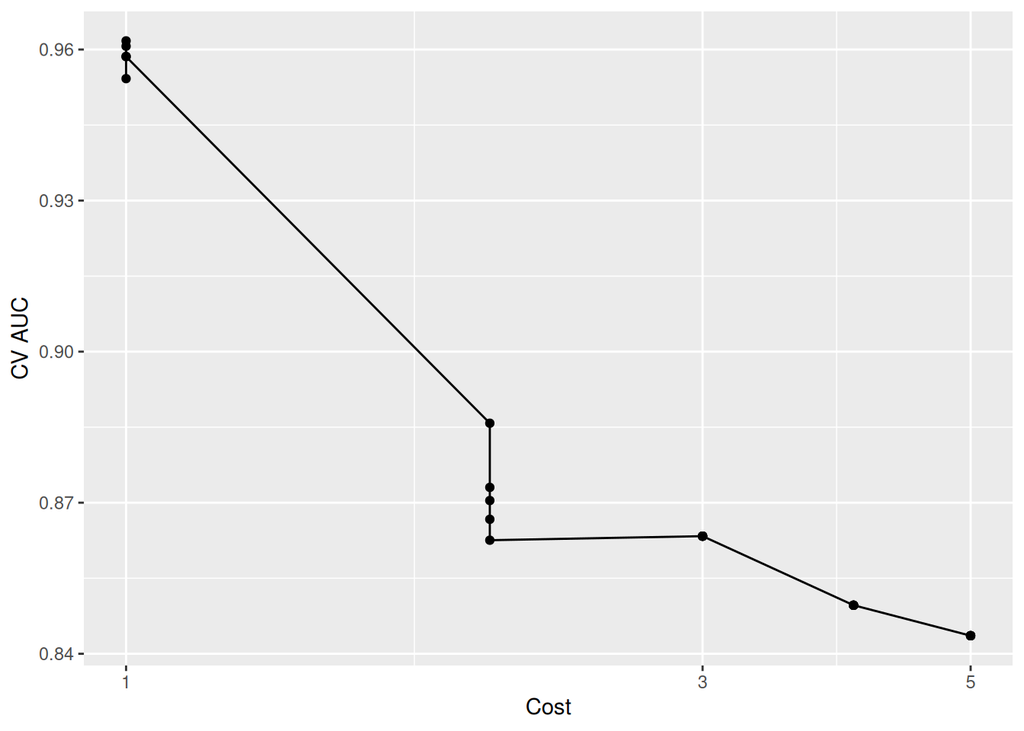

```r
#Visualize CV results
svm_fit %>%
  collect_metrics() %>%
  filter(.metric == "roc_auc") %>%
  ggplot(mapping = aes(x = degree, y = mean)) +
  geom_point() +
  geom_line() +
  labs(x = "Cost", y = "CV AUC") +
  scale_x_log10()
```

```r
svm_fit %>%
  show_best(metric = "roc_auc")
```

```
# A tibble: 5 × 8
   cost degree .metric .estimator  mean     n std_err .config
  <dbl>  <dbl> <chr>   <chr>      <dbl> <int>   <dbl> <chr>
1 1          1 roc_auc binary     0.962     5  0.0124 Preprocessor1_Model03
2 2.83       1 roc_auc binary     0.961     5  0.0115 Preprocessor1_Model04
3 0.354      1 roc_auc binary     0.959     5  0.0127 Preprocessor1_Model02
4 8          1 roc_auc binary     0.959     5  0.0121 Preprocessor1_Model05
5 0.125      1 roc_auc binary     0.954     5  0.0116 Preprocessor1_Model01
```

```r
best_svm <- svm_fit %>%
  select_best(metric = "roc_auc")
best_svm
```

```
# A tibble: 1 × 3
   cost degree .config
  <dbl>  <dbl> <chr>
1     1      1 Preprocessor1_Model03
```

#### 3.2.4 Finalize the model

```r
final_wf <- svm_wf %>%
  finalize_workflow(best_svm)
final_wf
```

```
══ Workflow ════════════════════════════════════════════════════════════════════
Preprocessor: Recipe
Model: svm_poly()

── Preprocessor ────────────────────────────────────────────────────────────────
3 Recipe Steps

• step_dummy()
• step_zv()
• step_normalize()

── Model ───────────────────────────────────────────────────────────────────────
Polynomial Support Vector Machine Model Specification (classification)

Main Arguments:
  cost = 1
  degree = 1

Computational engine: kernlab
```

```r
final_fit <-
  final_wf %>%
  last_fit(data_split)
final_fit
```

```
# Resampling results
# Manual resampling
# A tibble: 1 × 6
  splits            id               .metrics .notes   .predictions .workflow
  <list>            <chr>            <list>   <list>   <list>       <list>
1 <split [300/100]> train/test split <tibble> <tibble> <tibble>     <workflow>
```

```r
final_fit %>%
  collect_metrics()
```

```
# A tibble: 3 × 4
  .metric     .estimator .estimate .config
  <chr>       <chr>          <dbl> <chr>
1 accuracy    binary        0.84   Preprocessor1_Model1
2 roc_auc     binary        0.944  Preprocessor1_Model1
3 brier_class binary        0.0987 Preprocessor1_Model1
```

#### 3.2.5 Visualize the final model

```r
set.seed(212)
split_obj <- initial_split(data = Carseats, prop = 0.75, strata = Sales)
train <- training(split_obj)
test <- testing(split_obj)


# Create the recipe
recipe(Sales ~ ., data = train) %>%
  # create traditional dummy variables (necessary for svm)
  step_dummy(all_nominal_predictors()) %>%
  # zero-variance filter
  step_zv(all_numeric_predictors()) %>%
  # center and scale numeric data
  step_normalize(all_numeric_predictors()) %>%
  # estimate the means and standard deviations
  prep() -> recipe_obj

# Bake
train <- bake(recipe_obj, new_data=train)
test <- bake(recipe_obj, new_data=test)
```

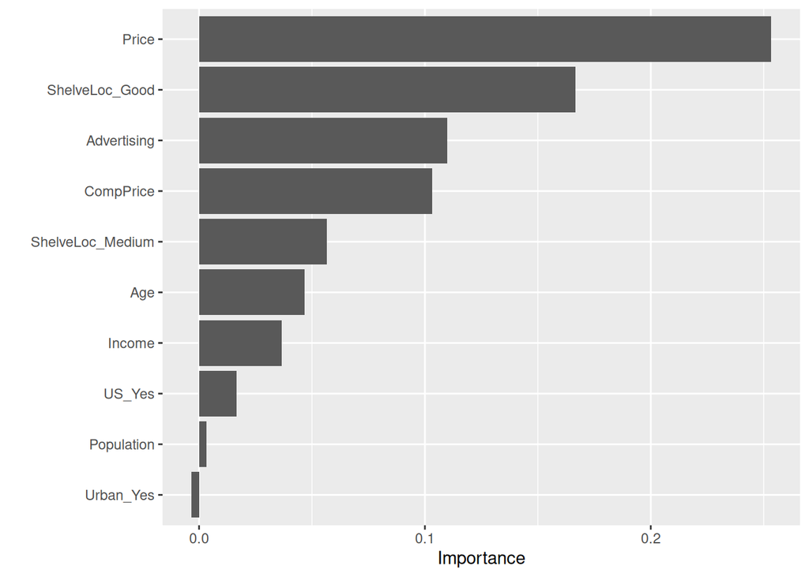

```r
final_fit %>%
  pluck(".workflow", 1) %>%
  pull_workflow_fit() %>%
  vip(method = "permute",
      target = "Sales", metric = "accuracy",
      pred_wrapper = kernlab::predict, train = train)
```

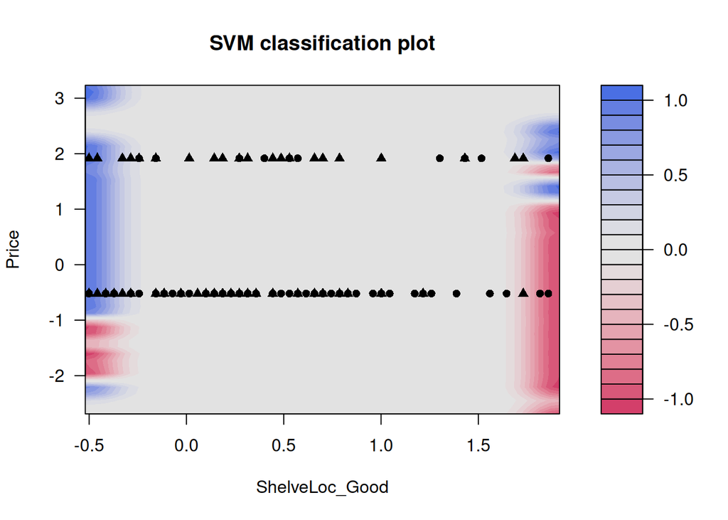

```r
# Use svm_poly() for polynomial kernel SVM
svm_rbf_spec <- svm_rbf() %>%
  set_mode("classification") %>%
  set_engine("kernlab")

svm_rbf_fit <- svm_rbf_spec %>%
  fit(Sales ~ ., data = train[, c('Price', 'ShelveLoc_Good', 'Sales')])

svm_rbf_fit %>%
  extract_fit_engine() %>%
  plot()
```

### 3.3 SVM with radial kernel

#### 3.3.1 Model & Workflow

```r
svm_mod <-
  svm_rbf(
    mode = "classification",
    cost = tune(),
    rbf_sigma = tune()
  ) %>%
  set_engine("kernlab")
svm_mod
```

```
Radial Basis Function Support Vector Machine Model Specification (classification)

Main Arguments:
  cost = tune()
  rbf_sigma = tune()

Computational engine: kernlab
```

```r
svm_wf <- workflow() %>%
  add_recipe(svm_recipe) %>%
  add_model(svm_mod)
svm_wf
```

```
══ Workflow ════════════════════════════════════════════════════════════════════
Preprocessor: Recipe
Model: svm_rbf()

── Preprocessor ────────────────────────────────────────────────────────────────
3 Recipe Steps

• step_dummy()
• step_zv()
• step_normalize()

── Model ───────────────────────────────────────────────────────────────────────
Radial Basis Function Support Vector Machine Model Specification (classification)

Main Arguments:
  cost = tune()
  rbf_sigma = tune()

Computational engine: kernlab
```

#### 3.3.2 Tuning grid

```r
param_grid <- grid_regular(
  cost(range = c(-8, 5)),
  rbf_sigma(range = c(-5, -3)),
  levels = c(14, 5)
  )
param_grid
```

```
# A tibble: 70 × 2
      cost rbf_sigma
     <dbl>     <dbl>
 1 0.00391   0.00001
 2 0.00781   0.00001
 3 0.0156    0.00001
 4 0.0312    0.00001
 5 0.0625    0.00001
 6 0.125     0.00001
 7 0.25      0.00001
 8 0.5       0.00001
 9 1         0.00001
10 2         0.00001
# ℹ 60 more rows
```

#### 3.3.3 Cross-validation

```r
set.seed(212)

folds <- vfold_cv(Carseats_other, v = 5)
folds
```

```
#  5-fold cross-validation
# A tibble: 5 × 2
  splits           id
  <list>           <chr>
1 <split [240/60]> Fold1
2 <split [240/60]> Fold2
3 <split [240/60]> Fold3
4 <split [240/60]> Fold4
5 <split [240/60]> Fold5
```

```r
svm_fit <- svm_wf %>%
  tune_grid(
    resamples = folds,
    grid = param_grid,
    metrics = metric_set(roc_auc, accuracy)
    )
svm_fit
```

```
# Tuning results
# 5-fold cross-validation
# A tibble: 5 × 4
  splits           id    .metrics           .notes
  <list>           <chr> <list>             <list>
1 <split [240/60]> Fold1 <tibble [140 × 6]> <tibble [0 × 3]>
2 <split [240/60]> Fold2 <tibble [140 × 6]> <tibble [0 × 3]>
3 <split [240/60]> Fold3 <tibble [140 × 6]> <tibble [0 × 3]>
4 <split [240/60]> Fold4 <tibble [140 × 6]> <tibble [0 × 3]>
5 <split [240/60]> Fold5 <tibble [140 × 6]> <tibble [0 × 3]>
```

```
# A tibble: 140 × 8
      cost rbf_sigma .metric  .estimator  mean     n std_err
     <dbl>     <dbl> <chr>    <chr>      <dbl> <int>   <dbl>
 1 0.00391   0.00001 accuracy binary     0.59      5  0.0319
 2 0.00391   0.00001 roc_auc  binary     0.883     5  0.0218
 3 0.00781   0.00001 accuracy binary     0.59      5  0.0319
 4 0.00781   0.00001 roc_auc  binary     0.883     5  0.0218
 5 0.0156    0.00001 accuracy binary     0.59      5  0.0319
 6 0.0156    0.00001 roc_auc  binary     0.883     5  0.0218
 7 0.0312    0.00001 accuracy binary     0.59      5  0.0319
 8 0.0312    0.00001 roc_auc  binary     0.883     5  0.0218
 9 0.0625    0.00001 accuracy binary     0.59      5  0.0319
10 0.0625    0.00001 roc_auc  binary     0.883     5  0.0218
   .config
   <chr>
 1 Preprocessor1_Model01
 2 Preprocessor1_Model01
 3 Preprocessor1_Model02
 4 Preprocessor1_Model02
 5 Preprocessor1_Model03
 6 Preprocessor1_Model03
 7 Preprocessor1_Model04
 8 Preprocessor1_Model04
 9 Preprocessor1_Model05
10 Preprocessor1_Model05
# ℹ 130 more rows
```

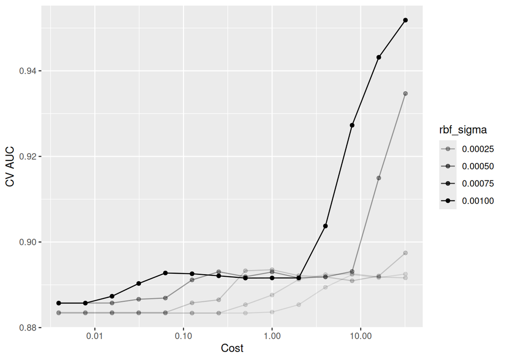

```r
svm_fit %>%
  collect_metrics() %>%
  print(width = Inf) %>%
  filter(.metric == "roc_auc") %>%
  ggplot(mapping = aes(x = cost, y = mean, alpha = rbf_sigma)) +
  geom_point() +
  geom_line(aes(group = rbf_sigma)) +
  labs(x = "Cost", y = "CV AUC") +
  scale_x_log10()
```

```r
svm_fit %>%
  show_best(metric = "roc_auc")
```

```
# A tibble: 5 × 8
   cost rbf_sigma .metric .estimator  mean     n std_err .config
  <dbl>     <dbl> <chr>   <chr>      <dbl> <int>   <dbl> <chr>
1    32  0.001    roc_auc binary     0.952     5  0.0110 Preprocessor1_Model70
2    16  0.001    roc_auc binary     0.943     5  0.0117 Preprocessor1_Model69
3    32  0.000316 roc_auc binary     0.935     5  0.0117 Preprocessor1_Model56
4     8  0.001    roc_auc binary     0.927     5  0.0155 Preprocessor1_Model68
5    16  0.000316 roc_auc binary     0.915     5  0.0162 Preprocessor1_Model55
```

```r
best_svm <- svm_fit %>%
  select_best(metric = "roc_auc")
best_svm
```

```
# A tibble: 1 × 3
   cost rbf_sigma .config
  <dbl>     <dbl> <chr>
1    32     0.001 Preprocessor1_Model70
```

#### 3.3.4 Finalize the model

```r
# Final workflow
final_wf <- svm_wf %>%
  finalize_workflow(best_svm)
final_wf
```

```
══ Workflow ════════════════════════════════════════════════════════════════════
Preprocessor: Recipe
Model: svm_rbf()

── Preprocessor ────────────────────────────────────────────────────────────────
3 Recipe Steps

• step_dummy()
• step_zv()
• step_normalize()

── Model ───────────────────────────────────────────────────────────────────────
Radial Basis Function Support Vector Machine Model Specification (classification)

Main Arguments:
  cost = 32
  rbf_sigma = 0.001

Computational engine: kernlab
```

```r
# Fit the whole training set, then predict the test cases
final_fit <-
  final_wf %>%
  last_fit(data_split)
final_fit
```

```
# Resampling results
# Manual resampling
# A tibble: 1 × 6
  splits            id               .metrics .notes   .predictions .workflow
  <list>            <chr>            <list>   <list>   <list>       <list>
1 <split [300/100]> train/test split <tibble> <tibble> <tibble>     <workflow>
```

```r
# Test metrics
final_fit %>%
  collect_metrics()
```

```
# A tibble: 3 × 4
  .metric     .estimator .estimate .config
  <chr>       <chr>          <dbl> <chr>
1 accuracy    binary        0.89   Preprocessor1_Model1
2 roc_auc     binary        0.959  Preprocessor1_Model1
3 brier_class binary        0.0773 Preprocessor1_Model1
```

```r
# Test metrics
final_fit %>%
  collect_metrics()
```

```
# A tibble: 3 × 4
  .metric     .estimator .estimate .config
  <chr>       <chr>          <dbl> <chr>
1 accuracy    binary        0.89   Preprocessor1_Model1
2 roc_auc     binary        0.959  Preprocessor1_Model1
3 brier_class binary        0.0773 Preprocessor1_Model1
```

#### 3.3.5 Visualize the final model

```r
set.seed(212)
split_obj <- initial_split(data = Carseats, prop = 0.75, strata = Sales)
train <- training(split_obj)
test <- testing(split_obj)


# Create the recipe
recipe(Sales ~ ., data = train) %>%
  # create traditional dummy variables (necessary for svm)
  step_dummy(all_nominal_predictors()) %>%
  # zero-variance filter
  step_zv(all_numeric_predictors()) %>%
  # center and scale numeric data
  step_normalize(all_numeric_predictors()) %>%
  # estimate the means and standard deviations
  prep() -> recipe_obj

# Bake
train <- bake(recipe_obj, new_data=train)
test <- bake(recipe_obj, new_data=test)
```

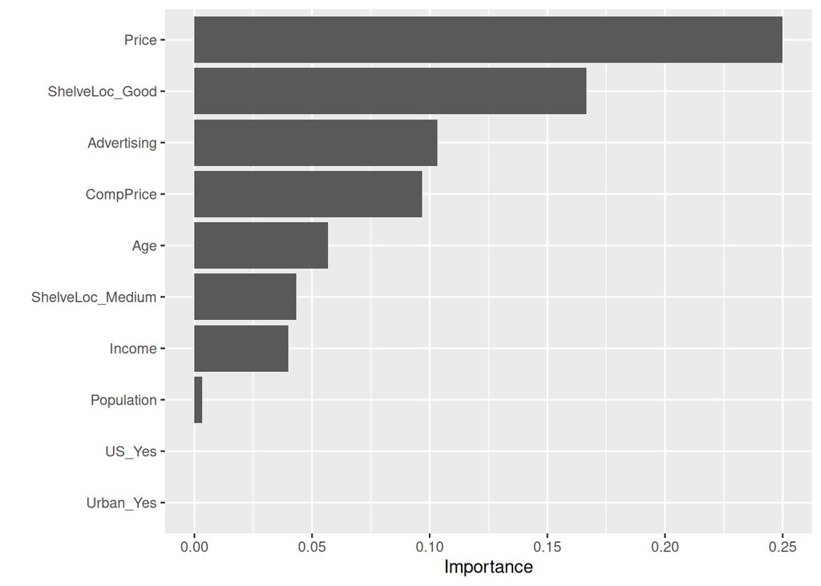

```r
final_fit %>%
  pluck(".workflow", 1) %>%
  pull_workflow_fit() %>%
  vip(method = "permute",
      target = "Sales", metric = "accuracy",
      pred_wrapper = kernlab::predict, train = train)
```

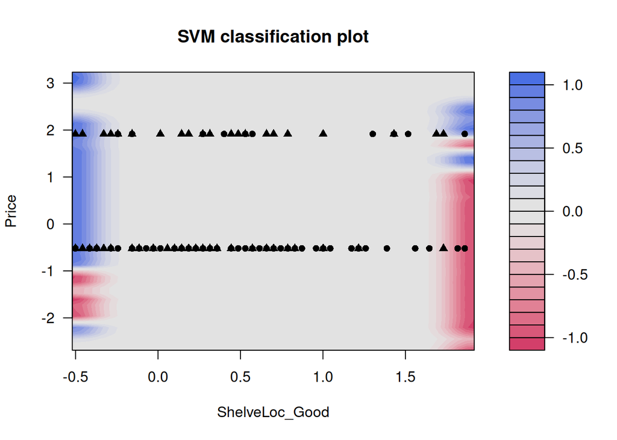

```r
# Use svm_rbf() for RBF kernel SVM
svm_rbf_spec <- svm_rbf() %>%
  set_mode("classification") %>%
  set_engine("kernlab")

# Fit the model with RBF kernel
svm_rbf_fit <- svm_rbf_spec %>%
  fit(Sales ~ ., data = train[, c('Price', 'ShelveLoc_Good', 'Sales')])

# Visualize the decision boundary
svm_rbf_fit %>%
  extract_fit_engine() %>%
  plot()
```

### 3.4 Conlusion:

After comparing the accuracy and roc_auc of each model, the SVM with radial kernel has the highest value, so we choose it as the final model.

## 4 Bonus (10pts)

Let
$$f(X) = \beta_0 + \beta_1 X_1 + \cdots + \beta_p X_p = \beta_0 + \beta^T X.$$
Then $f(X)=0$ defines a hyperplane in $\mathbb{R}^p$. Show that $f(x)$ is proportional to the signed distance of a point $x$ to the hyperplane $f(X) = 0$.